# Kışokulu 2020 - R ile transkriptom analizi

Mehmet Somel

16/01/2020

# Hedefler

Burada basit bir transkriptom veri setini inceleyerek:

- Karşılaştırmalı transkriptom verisi ile cevaplanabilecek soruları tartışacak,
- Veriyi işlemek ve çözümlemek için kullanılan kimi temel yöntemleri uygulayacak,
- Eleştirel bir yaklaşımla, hem verinin hem de kullanılan araçların sınırlarını tanıyacak,
- R yeteneklerinizi geliştirecek,
- Güncel RNA dizileme araçlarını da kısaca öğreneceksiniz.

# Veri setine giriş

Burada uzun zaman önce yayımlanmış bir **primat karaciğer transkriptom** veri setini inceleyeceğiz [Blekhman vd. 2010 Genome Research](https://www.ncbi.nlm.nih.gov/pubmed/20009012).

Ham veya kısmen işlenmiş veriyi NCBI GEO’dan indirebilirsiniz: https://www.ncbi.nlm.nih.gov/geo/query/acc.cgi?acc=GSE17274. Burada kullanacağımız veriler de sayfanın sonundaki (“GSE17274_ReadCountPerLane.txt.gz”) veri setinin bir türevi (işlenmiş hali) olacak.

### Veri setinin içeriği

- 6 insan, 6 şempanze, 6 şebek (rhesus macaque),
- her türden 3 dişi ve 3 erkek,
- her bireyden 2 teknik replika.

### Verinin üretim aşamaları

Deney kapsamında **postmortem karaciğer** örnekleri şu şekilde işlendi:

1. Total RNA -> polyA mRNA -> cDNA -> rastgele parçalama -> kütüphane hazırlama,
2. Illumina Genome Analyzer2 RNA-dizileme,
- 35-bp tek yönlü okuma,
- örnek başına 6-7 milyon okuma.

### Veri seti hazırlanırken kullanılan veri işleme adımları

Tek bir türün RNA-dizileme verisi işleniyor olsaydı, okumalarımızı

1. bu türe veya yakın bir türrer ait bir **genom anotasyon dosyasına (.gtf)** veya,
2. kendi okumalarımızı birbirine üleştirerek oluşturabileceğimiz **de novo contiglere**,

hizalayıp gen ifadesi ölçebilirdik. Ancak burada **farklı türler** karşılaştırılacağı için işlem daha zor.

Orijinal makalede şu adımlar kullanılmış:

1. [Ensembl veritabanından](https://www.ensembl.org/index.html) her üç türün ekzonları indirilmiş,
2. Bu ekzonlar türler arasında BLAT ile birbirine hizalanarak, **1:1 ortolog ekzonlar** bulunmuş (20.689 gen için 150.107 ekzon).
3. Okumalar bu ekzon setine hizalanmış.
4. **Tek bir bölgeye** tartışmasız hizalanan okumalar seçilmiş,
5. Bir gene ait tüm ekzonlara hizalanan okumaların toplamı o genin o örnekteki gen ifadesi seviyesi olarak alınmış.

GEO’dan indirebileceğiniz veri seti bu aşamaya ait. Makalede bunun ötesinde şu ön işleme adımları da yürütülmüş:

6. Normalizasyon: Beşinci adımda elde edilen ifade değeri, o örnekteki toplam okuma miktarına bölünüp 1 milyonla çarpılmış.
7. Değerler, kare kökleri alınarak dönüştürülmüş.

### Bu tip veriyle ne tip sorular inceleyebiliriz?

- Türler arasında anlamlı gen ifadesi farkı (İng. differential expression) gösteren genlerin oranı nedir?
- Hangi tür diğerlerinden gen ifadesi açısından daha farklı?
- Fark gösteren genlerin özgün işlevleri var mı? Varsa neler?
- Cinsiyet etkisi var mı? Türler arasında tutarlı bir cinsiyet etkisi görebilir miyiz?
- Cinsiyetler arasında fark gösteren genler cinsiyet kromomlarında mı yoğunlaşmış?

Buradan yol çıkarak,

- Transkriptom farklılaşması ortama / diyete plastik tepkileri mi yansıtıyor?
- Ya da ortak kökeni ve soyoluşu mu yansıtıyor?
- Ya da türe özgü uyarlanımları mı yansıtıyor?

Bu soruların bir kısmını kurs sırasında inceleyeceğiz.

## Bu çalışmada yapacağımız:

Bu derste yürüteceğimiz işlemlerin üç aşaması var:

1. Verinin ön işlemesi ve kalite kontrolü:
- Genel inceleme,
- Log-dönüştürme,
- Sütunlar arasında normalizasyon,
- Örnekler arasındaki genel varyasyonun hiyerarşik kümeleme ve temel bileşenler analizi ile incelenmesi.
2. Türler ve cinsiyetler arasında gen ifadesi farklarının belirlenmesi:
- ANOVA modelleri ile gen ifadesi farklarının bulunması,
- Çoklu test düzeltmesi uygulanması.
3. İfade farkı gösteren genlerin işlevsel çözümlemesi:
- Cinsiyet farkı gösteren genlerin cinsiyet kromozomlarında yoğunlaştığı hipotezinin testi.

## Burada işlemediğimiz konular:

Burada işlemediğimiz ama size iletilen ek belgede takip edebileceğiniz işlemler: + Orijinal veri setinde teknik replikaların birleştirilmesi, + Düşük ifadeli genlerin elenmesi, + İfade farkı için (ANOVA’ya alternatif) permütasyon testi, + İfade farkını alternatif modellerle inceleme (lineer modeller, rastgele etken içeren modeller, vs.), + İfade farkını “DESeq2” paketiyle çözümleme, + İfade farkı gösteren genleri k-ortalama yöntemiyle kümeleme, + İfade farkı gösteren genlerin işlevlerini “Gene Ontology” veri tabanıyla inceleme.

Şunu vurgulamak önemli: Burada anlatılan deney tasarımı, okuma verisi işleme yöntemleri, ayrıca burada kullanılan ön işleme ve ifade farkı belirleme yöntemleri güncel standartları birçok açıdan karşılamıyor, ya da en az burada anlatılanlar kadar iyi alternatifler mevcut. Burada yalnızca sürecin temellerini tanımayı hedefliyoruz.

Size iletilen ek belgede güncel yöntemlere dair bilgi bulabilirsiniz. Yine aynı belgede transkriptom çalışmalarında cevaplanabilecek farklı sorular ve bu tip verinin değerli yanları ve zayıflıklarına dair bir tartışma da mevcut.

# VERİYİ OKUMA VE İNCELEME

```r
# Önce çalışma klasörünü verinin olduğu yere taşıyalım
setwd("/truba/home/egitim/Admin/Data/Mehmet/")
```

```r
# İçindeki dosyaları kontrol edelim
list.files()
```

```
##  [1] "20190325_berlin_compexprs_code.tex"
##  [2] "20200116_kisokulu_exprs.Rmd"
##  [3] "GSE17274_ReadCountPerLane.txt"
##  [4] "GSE17274_ReadCountPerLane_summarized_filtered.txt"
##  [5] "TODO!!!"
##  [6] "ex.tre"
##  [7] "nfmat3_aovp.Rdata"
##  [8] "nlmat_aovp.Rdata"
##  [9] "perm_nfmat3_aovp.RData"
## [10] "perm_nfmat3_aovp2.RData"
## [11] "summarized_filtered_dataset.R"
```

```r
# Verileri okuyalım
mat <- read.table(
  "GSE17274_ReadCountPerLane_summarized_filtered.txt", row.names=1, head=T, sep=" " )
# head=T: ilk satır sütun isimleri
# row.names=1: ilk sütun satır isimleri
# sep=" ": ayraç boşluk
```

Şimdi veriyi inceleyelim:

```r
str(mat)
```

```
## 'data.frame':    10644 obs. of  18 variables:
##  $ HSM1: num  60.5 19.5 57 7.5 36.5 1800 100 168 14.5 14 ...
##  $ PTF1: num  287 50 65.5 4 42 ...
##  $ RMM1: num  212 24.5 58.5 3.5 40 ...
##  $ HSF1: num  164.5 40.5 45.5 3 22 ...
##  $ PTM1: num  204.5 29.5 137 6 99 ...
##  $ RMF1: num  255.5 33.5 44.5 2 36.5 ...
##  $ RMF2: num  232 36 34.5 2 14 ...
##  $ HSM2: num  210.5 39 36.5 3.5 21.5 ...
##  $ PTF2: num  214 33 114 4 52 ...
##  $ RMM2: num  674 41 57 1.5 17 ...
##  $ HSF2: num  150 30.5 31 8.5 32.5 ...
##  $ PTM2: num  342.5 29 119.5 3.5 15.5 ...
##  $ RMM3: num  352.5 45 81.5 2 36 ...
##  $ RMF3: num  240 28.5 59 5 27 ...
##  $ HSM3: num  179.5 31 47.5 8.5 32.5 ...
##  $ PTF3: num  193 32.5 43.5 2.5 38 ...
##  $ PTM3: num  214 46.5 74.5 5 29 ...
##  $ HSF3: num  84 28 38 6 105 ...
```

```r
class(mat)
```

```
## [1] "data.frame"
```

```r
# Boyutlarını inceleyelim - beklediiniz gibi mi?
dim(mat)
```

```
## [1] 10644    18
```

```r
# Başı ve ...
head(mat)
```

|  | HSM1 | PTF1 | RMM1 | HSF1 | PTM1 | RMF1 | RMF2 | HSM2 | PTF2 | RMM2 | HSF2 | PTM2 | RMM3 | RMF3 | HSM3 | PTF3 | PTM3 | HSF3 |
| --- | --- | --- | --- | --- | --- | --- | --- | --- | --- | --- | --- | --- | --- | --- | --- | --- | --- | --- |
| ENSG00000000003 | 60.5 | 287.0 | 212.0 | 164.5 | 204.5 | 255.5 | 232.0 | 210.5 | 214.5 | 674.0 | 150.0 | 342.5 | 352.5 | 240.0 | 179.5 | 193.0 | 214.0 | 84.0 |
| ENSG00000000419 | 19.5 | 50.0 | 24.5 | 40.5 | 29.5 | 33.5 | 36.0 | 39.0 | 33.0 | 41.0 | 30.5 | 29.0 | 45.0 | 28.5 | 31.0 | 32.5 | 46.5 | 28.0 |
| ENSG00000000457 | 57.0 | 65.5 | 58.5 | 45.5 | 137.0 | 44.5 | 34.5 | 36.5 | 114.5 | 57.0 | 31.0 | 119.5 | 81.5 | 59.0 | 47.5 | 43.5 | 74.5 | 38.0 |
| ENSG00000000460 | 7.5 | 4.0 | 3.5 | 3.0 | 6.0 | 2.0 | 2.0 | 3.5 | 4.0 | 1.5 | 8.5 | 3.5 | 2.0 | 5.0 | 8.5 | 2.5 | 5.0 | 6.0 |
| ENSG00000000938 | 36.5 | 42.0 | 40.0 | 22.0 | 99.0 | 36.5 | 14.0 | 21.5 | 52.0 | 17.0 | 32.5 | 15.5 | 36.0 | 27.0 | 32.5 | 38.0 | 29.0 | 105.0 |
| ENSG00000000971 | 1800.0 | 2691.0 | 7118.0 | 2382.5 | 1284.0 | 6783.0 | 4982.0 | 3191.5 | 4165.5 | 2598.0 | 3612.5 | 2509.5 | 5917.0 | 9123.5 | 2773.0 | 2167.5 | 1326.5 | 1702.5 |

```r
tail(mat)
```

|  | HSM1 | PTF1 | RMM1 | HSF1 | PTM1 | RMF1 | RMF2 | HSM2 | PTF2 | RMM2 | HSF2 | PTM2 | RMM3 | RMF3 | HSM3 | PTF3 | PTM3 | HSF3 |
| --- | --- | --- | --- | --- | --- | --- | --- | --- | --- | --- | --- | --- | --- | --- | --- | --- | --- | --- |
| ENSG00000220685 | 0.5 | 5.5 | 3.5 | 3.5 | 3.5 | 6.0 | 2.5 | 5.0 | 4.5 | 4.5 | 3.0 | 5.0 | 11.5 | 10.5 | 2.5 | 9.0 | 0.5 | 1.0 |
| ENSG00000220820 | 30.5 | 28.0 | 21.0 | 10.0 | 32.0 | 11.5 | 10.5 | 6.5 | 37.0 | 12.5 | 10.0 | 42.0 | 52.0 | 15.5 | 35.0 | 26.5 | 41.0 | 10.5 |
| ENSG00000220914 | 2.0 | 1.0 | 5.0 | 4.5 | 1.5 | 9.0 | 1.5 | 5.5 | 8.0 | 22.5 | 2.5 | 2.0 | 3.5 | 6.0 | 6.0 | 3.0 | 4.0 | 0.5 |
| ENSG00000220949 | 10.5 | 15.5 | 22.5 | 15.0 | 14.0 | 24.0 | 13.5 | 17.0 | 11.5 | 12.0 | 12.0 | 15.0 | 20.5 | 11.5 | 13.5 | 8.0 | 13.0 | 14.0 |
| ENSG00000221420 | 0.5 | 1.5 | 4.5 | 1.0 | 4.0 | 1.5 | 3.5 | 1.0 | 1.0 | 4.5 | 0.5 | 1.5 | 4.0 | 2.5 | 0.5 | 1.0 | 0.5 | 2.0 |
| ENSG00000221539 | 1.5 | 2.0 | 2.5 | 1.0 | 3.0 | 1.5 | 1.0 | 1.0 | 2.0 | 1.5 | 1.0 | 0.5 | 1.0 | 0.5 | 0.5 | 1.0 | 2.5 | 2.5 |

```r
# Sütun isimlerini görelim
colnames(mat)
```

```
##  [1] "HSM1" "PTF1" "RMM1" "HSF1" "PTM1" "RMF1" "RMF2" "HSM2" "PTF2" "RMM2"
## [11] "HSF2" "PTM2" "RMM3" "RMF3" "HSM3" "PTF3" "PTM3" "HSF3"
```

```r
# Satır isimlerine de bir bakalım (ama sadece ilk baştakilere)
head( rownames(mat)  )
```

```
## [1] "ENSG00000000003" "ENSG00000000419" "ENSG00000000457" "ENSG00000000460"
## [5] "ENSG00000000938" "ENSG00000000971"
```

`data.frame` nesneleri karmaşık verileri (ör. sayı + karakter) saklamak için uygun, ama bizim verimiz sadece sayısal. R’da sayısal veriyle çalışan bazı işlevler girdi olarak `data.frame` nesne sınıfını kabul etmediği (ve bazen sayısal veriye `factor` muamelesi yaptığı için) biz verimizi `matrix`e çevirelim:

```r
mat <- as.matrix(mat)
# Her işlemden sonra doğru çalıştığını kontrol edelim
head(mat)
```

```
##                   HSM1   PTF1   RMM1   HSF1   PTM1   RMF1   RMF2   HSM2   PTF2
## ENSG00000000003   60.5  287.0  212.0  164.5  204.5  255.5  232.0  210.5  214.5
## ENSG00000000419   19.5   50.0   24.5   40.5   29.5   33.5   36.0   39.0   33.0
## ENSG00000000457   57.0   65.5   58.5   45.5  137.0   44.5   34.5   36.5  114.5
## ENSG00000000460    7.5    4.0    3.5    3.0    6.0    2.0    2.0    3.5    4.0
## ENSG00000000938   36.5   42.0   40.0   22.0   99.0   36.5   14.0   21.5   52.0
## ENSG00000000971 1800.0 2691.0 7118.0 2382.5 1284.0 6783.0 4982.0 3191.5 4165.5
##                   RMM2   HSF2   PTM2   RMM3   RMF3   HSM3   PTF3   PTM3   HSF3
## ENSG00000000003  674.0  150.0  342.5  352.5  240.0  179.5  193.0  214.0   84.0
## ENSG00000000419   41.0   30.5   29.0   45.0   28.5   31.0   32.5   46.5   28.0
## ENSG00000000457   57.0   31.0  119.5   81.5   59.0   47.5   43.5   74.5   38.0
## ENSG00000000460    1.5    8.5    3.5    2.0    5.0    8.5    2.5    5.0    6.0
## ENSG00000000938   17.0   32.5   15.5   36.0   27.0   32.5   38.0   29.0  105.0
## ENSG00000000971 2598.0 3612.5 2509.5 5917.0 9123.5 2773.0 2167.5 1326.5 1702.5
```

```r
class(mat)
```

```
## [1] "matrix"
```

Sütun isimlerinde bireylerin bilgisi mevcut:

- tür (HS: Homo sapiens, PT: Pan troglodytes, RM: rhesus macaque),
- cinsiyet (F: dişi, M: erkek),
- birey numarası.

Örneğin **PTF3**, üçüncü dişi şempanze.

## Boxplot ile dağılımları inceleme

Veriyi hızlıca özetleyerek incelemenin bir yolu, dağılımlara bakmak olabilir. Bunun için kutu grafikleri kullanabiliriz:

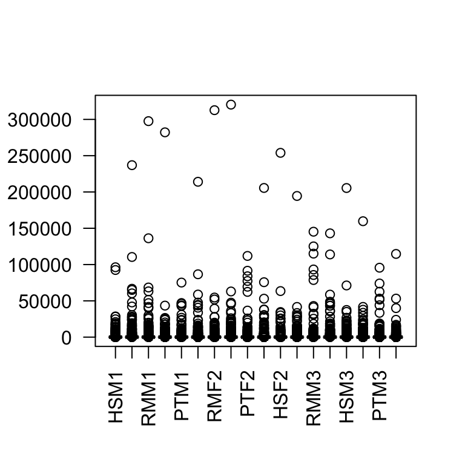

```r
# las=2: yazılar dikey basılsın
boxplot(mat, las=2)
```

Ne oluyor? Ya bir gariplik var, ya da veri dağılımı çok **çarpık** (İng. “skewed”), yani kapitalizmde gelir dağılımı gibi, çoğu düşük azı büyük.

İkincisi doğruysa, veriyi loglayarak biraz düzeltebiliriz. Yalnız loglamadan önce `1` ile toplamak mantıklı olur, ki `0` değerleri yokolmasın:

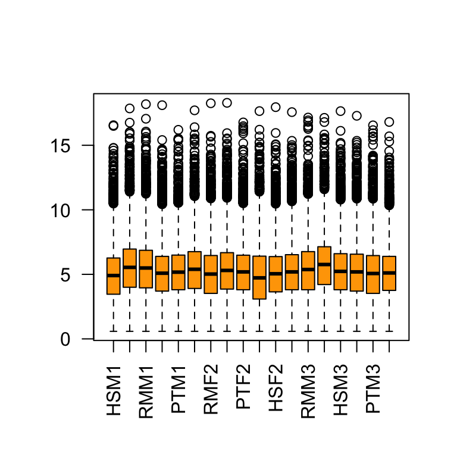

```r
boxplot(log2(mat+1), las=2, col='orange')
```

- Çarpık dağılım hipotezi doğru gözüküyor. Peki bu karaciğerde gen ifadesi manzarasına dair bize ne anlatıyor? Başka dokularda da aynı derece çarpıklık bekler miydiniz?
- Bireyler arasında dağılımlar az da olsa farklı. Buna daha sonra değineceğiz.

## Hiyerarşik kümeleme ile örnekler arasında farklılıkları inceleme

Veriyi daha yakından incelemek için ısı grafikleri (İng. “heatmap”) çizebilir veya örnekler arasında varyasyonu özetleyecek indirgeme teknikleri kullanabiliriz: mesela kümeleme, temel bileşenler analizi (PCA), çok boyutlu ölçeklendirme (MDS), vs. Bu yaklaşımlarla:

- Veri setindeki varyansın ana kaynaklarına dair bir fikir elde ederiz.
- Verideki olası anormallikleri, örneğin çıkıntı örnekleri (İng. “outlier”) tespit edebiliriz.

Burada **hiyerarşik kümeleme** uygulayacağız. UPGMA algoritmasını da içeren bu tip basit kümeleme işlemleri için R’da `hclust` fonksiyonunu kullanabiliyoruz.

Kümeleme için öncelikle bireyler arasında, yani matrisin sütunları arasında mesafe hesaplamak gerekiyor. Burada standart **Öklid mesafesini** (İng. “euclidean distance”) kullanacağız:

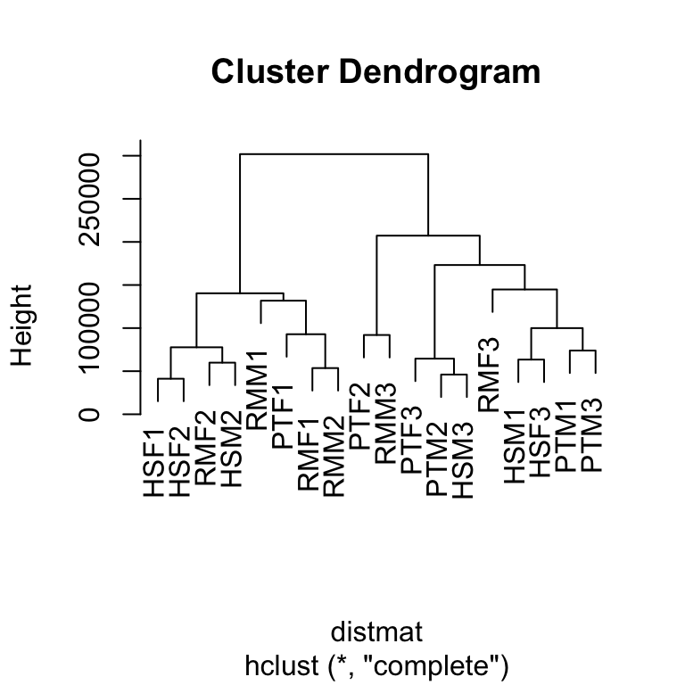

```r
distmat <- dist( t( mat ), method = "euclidean")
plot( hclust( distmat ) )
```

Ağaçta herhangi bir mantıklı biyolojik kümeleme görüyor musunuz? Veri çöp müymüş?

# VERİ DÖNÜŞTÜRME

Veri dönüştürmeden kastımız (İng. “data transformation”) deterministik bir fonksiyonun tüm veri setine uygulanması. Bu birçok biyolojik veri setinde kullanılan bir uygulama. Sebebini almak için verinin dağılımına bu sefer histogram kullanarak tekrar bir göz atalım:

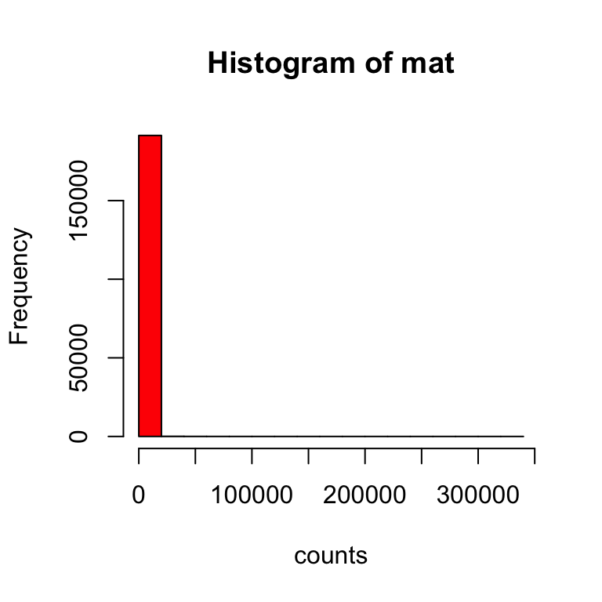

```r
hist( mat, col=2, xlab='counts' )
```

Demin gördüğümüz üzere veri çok eşitsiz, veya çarpık dağılıyor. Log veya kare kök alarak dağılımı normal dağılıma benzetmek mümkün. Log kullanıyorsak `0`ların `-Inf`e dönüşmesini engellemek için `1` ekleyebiliriz:

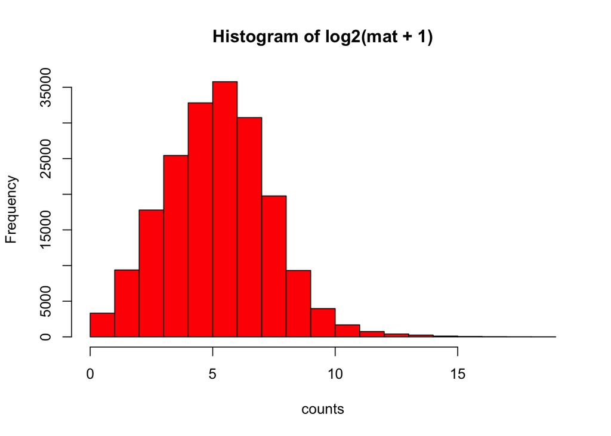

```r
hist( log2(mat + 1), col=2, xlab='counts' )
```

Faydası iki türlü:

1. Dönüştürme sayesinde yüksek değerlere düşük ağırlık vererek, verideki varyasyonu görmek ve **görselleştirmek** kolaylaşıyor,
2. Daha önemlisi, log dönüştürme ile kısmi **varyans stabilizasyonu** da sağlanır: ortalama ile varyans arasındaki güçlü pozitif korelasyondan kısmen kurtuluruz. Neden önemli? ANOVA gibi yöntemler gruplar arasında **benzer varyans** varsaydığı için, bir genin yüksek ve düşük seviyede anlatıldığı grupların ANOVA ile karşılaştırılması varyans stabilize edilmediği durumda uygun olmayabilir.

Bu işlemin ortalama-varyans ilişkisine etkisini ekteki belgede inceleyebilirsiniz.

Şimdi yeni bir loglanmış matris yaratalım ve buna eskisiyle karışmaması için `lmat` diye yeni bir isim verelim:

```r
lmat <- log2 ( mat + 1 )  # log transform
head( lmat )
```

```
##                      HSM1      PTF1      RMM1      HSF1      PTM1      RMF1
## ENSG00000000003  5.942515  8.169925  7.734710  7.370687  7.682995  8.002815
## ENSG00000000419  4.357552  5.672425  4.672425  5.375039  4.930737  5.108524
## ENSG00000000457  5.857981  6.055282  5.894818  5.539159  7.108524  5.507795
## ENSG00000000460  3.087463  2.321928  2.169925  2.000000  2.807355  1.584963
## ENSG00000000938  5.228819  5.426265  5.357552  4.523562  6.643856  5.228819
## ENSG00000000971 10.814582 11.394463 12.797459 11.218866 10.327553 12.727920
##                      RMF2      HSM2      PTF2      RMM2      HSF2      PTM2
## ENSG00000000003  7.864186  7.724514  7.751544  9.398744  7.238405  8.424166
## ENSG00000000419  5.209453  5.321928  5.087463  5.392317  4.977280  4.906891
## ENSG00000000457  5.149747  5.228819  6.851749  5.857981  5.000000  6.912889
## ENSG00000000460  1.584963  2.169925  2.321928  1.321928  3.247928  2.169925
## ENSG00000000938  3.906891  4.491853  5.727920  4.169925  5.066089  4.044394
## ENSG00000000971 12.282799 11.640471 12.024620 11.343741 11.819181 11.293759
##                      RMM3      RMF3      HSM3      PTF3      PTM3      HSF3
## ENSG00000000003  8.465566  7.912889  7.495855  7.599913  7.748193  6.409391
## ENSG00000000419  5.523562  4.882643  5.000000  5.066089  5.569856  4.857981
## ENSG00000000457  6.366322  5.906891  5.599913  5.475733  6.238405  5.285402
## ENSG00000000460  1.584963  2.584963  3.247928  1.807355  2.584963  2.807355
## ENSG00000000938  5.209453  4.807355  5.066089  5.285402  4.906891  6.727920
## ENSG00000000971 12.530894 13.155530 11.437752 11.082482 10.374496 10.734286
```

Acaba ne değişti? Bunu görmek için boxplot ve hiyerarşik kümelemeyi yineleyelim. Fark bekliyor musunuz?

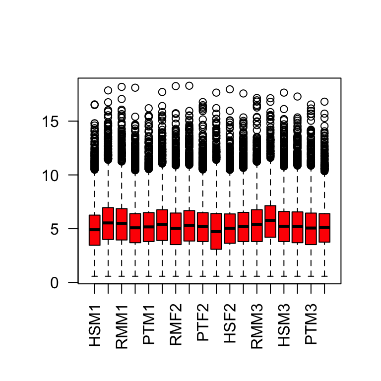

```r
boxplot( lmat, las=2, col=2)
```

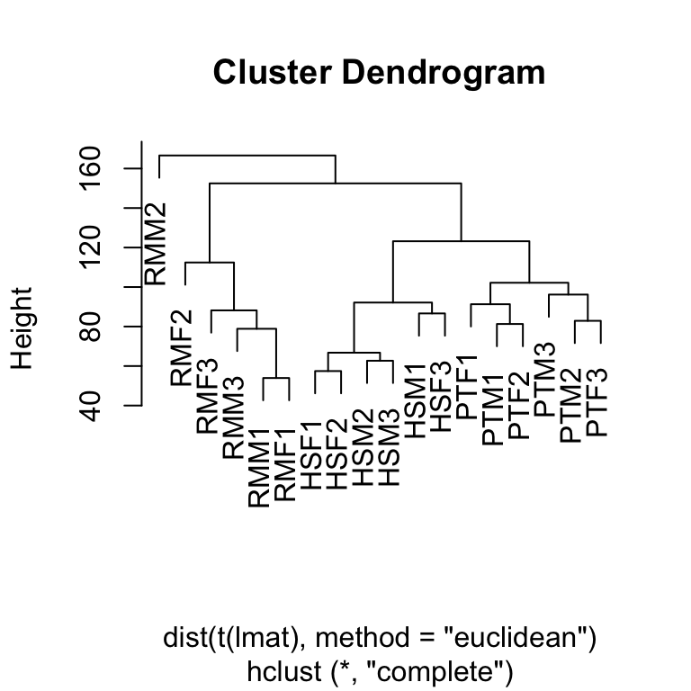

```r
plot( hclust( dist( t( lmat ), method = "euclidean")  ))
```

Abrakadabra! Şimdi biyolojik bir kümelenme görmeye başladık. Peki:

- log dönüştürmenin bu etkisini nasıl açıklayabilirsiniz?
- Sizce gördüğümüz kümelenme karaciğerde gen ifadesi evrimine dair ne söylüyor?

## Loglamak ya da loglamamak

Kimi bilge biyoistatistikçilerin veri dönüştürmeye düşman olduklarını, bunun yerine ham verinin çarpık dağılımını hesaba katan modeller kullanılmasını savunduklarını da bilmek önemli: https://www.r-bloggers.com/do-not-log-transform-count-data-bitches/.

Burada kolaylık olsun diye ANOVA kullanmak istediğimiz için log kullanıyoruz. Ancak dönüştürmenin potansiyel riskleri olabildiğini ve yalancı sonuçlara yol açabileceğini unutmamalı.

# YÜZDELİK (İNG. “QUANTİLE”) NORMALİZASYONU

Birçok transkriptom çalışmasında, gen gen yapılan varyans stabilizasyonunun yanısıra, **örnekler arasında karşılaştırmayı** daha uygun hale getirmek için bir normalizasyon da yürütülür.

Buradaki amaç, örnekler arasında ortalama gen ifadesi farklarına yol açabilen geniş çaplı teknik etkileri ortadan kaldırmaktır.

Motivasyonumuzu anlatmak için bireyler arasındaki farkları incelediğimiz kutu grafiğine geri dönelim.

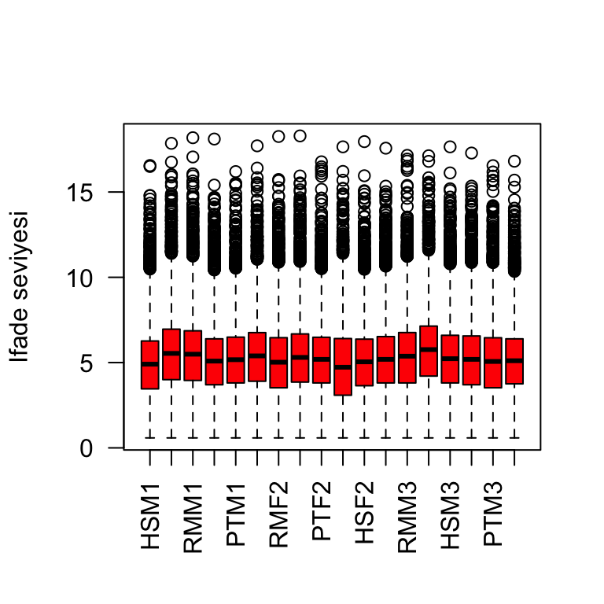

```r
boxplot( lmat, las=2, col=2, ylab='Ifade seviyesi')
```

Örnekler arasında sınırlı da olsa transkriptom çapında farklar göze çarpıyor. Deney her bir bireyden aynı miktarda total RNA ile başladığı için, bu farkların gerçek biyolojik farklar değil rastgele **teknik etkiler** olduğunu ve verimize gürültü olarak yansıyacağını varsayabiliriz. Bunları temizlemek veride gürültüyü azaltabilir. Burada kullanabileceğimiz bir yaklaşım **yüzdelik (İng. quantile) normalizasyonu**. Bu yöntem bireyler arasında gen ifadesi dağılımlarını tamamen aynı hale getiriyor (ama farklı genler farklı bireylede farklı değerlere sahip olmaya devam ediyor). [Şu adreste](http://pedagogix-tagc.univ-mrs.fr/courses/statistics_bioinformatics/practicals/ASG1_2012/affynorm_slides/index.html#/step-8) bir tasvirini bulabilirsiniz.

## Paket yükleme

Burada bir [Bioconductor](https://www.bioconductor.org/) paketi olan `preprocessCore` paketi içindeki `normalize.quantiles` fonksiyonunu kullanacağız.

Bu paketi [şu sayfadaki](https://www.bioconductor.org/packages/release/bioc/html/preprocessCore.html) komutlar uyarınca, aşağıdaki komutla bilgisayarımıza yükleyebiliriz (şu anda yürütmeyeceğiz):

```r
if (!requireNamespace("BiocManager", quietly = TRUE))
  install.packages("BiocManager")
BiocManager::install("preprocessCore", ask=F)
```

Bu arada R paketlerinin çoğunun Bioconductor’da değil, R’in genel paket veri tabanında olduğunu ve bunların `install.packages` komutuyla bilgisayara yüklenebildiğini bilelim.

Paketimiz halihazırda bilgisayarımızdaysa, mevcut R oturumuna yükleyebiliriz.

```r
library(preprocessCore, verbose = F, quietly = T)
```

Şimdi yüzdelik normalizasyonunu verimize uygulayalım, yeni matrisimize `nlmat` ve sonuçlarına bakalım:

```r
nlmat <- normalize.quantiles( lmat )
head(nlmat)
```

```
##           [,1]      [,2]      [,3]      [,4]      [,5]      [,6]      [,7]
## [1,]  6.272064  7.737762  7.479539  7.550515  7.872090  7.854719  7.964594
## [2,]  4.646554  5.339316  4.440764  5.499588  4.952473  4.927115  5.385744
## [3,]  6.186293  5.696404  5.640236  5.681293  7.243766  5.323365  5.323365
## [4,]  3.332702  2.090095  2.049153  1.969814  2.655443  1.518723  1.859787
## [5,]  5.535558  5.103876  5.086175  4.616573  6.748707  5.049150  4.096706
## [6,] 11.243480 10.924084 12.393432 11.446091 10.621892 12.437714 12.393432
##           [,8]      [,9]     [,10]     [,11]     [,12]     [,13]     [,14]
## [1,]  7.623875  7.895423  9.248657  7.458442  8.490831  8.275292  7.374670
## [2,]  5.233475  5.093608  5.746494  5.149629  4.891211  5.373117  4.383217
## [3,]  5.130976  6.987861  6.122070  5.168472  6.987492  6.184927  5.350802
## [4,]  2.022367  2.205102  1.897814  3.350319  2.053873  1.655235  2.215805
## [5,]  4.385196  5.783254  4.716572  5.245423  4.011325  5.057035  4.311916
## [6,] 11.507118 12.123923 11.196992 12.008199 11.415931 12.569526 12.569526
##          [,15]     [,16]     [,17]     [,18]
## [1,]  7.477059  7.595058  7.851797  6.617927
## [2,]  4.983589  5.101738  5.715780  4.950263
## [3,]  5.584066  5.497705  6.371020  5.396148
## [4,]  3.167048  1.870489  2.839844  2.705606
## [5,]  5.050355  5.298379  5.062384  6.942868
## [6,] 11.334391 10.955939 10.512792 11.113854
```

```r
# bu fonksiyon sütun ve satır isimlerini için, geri eklememiz gerekiyor
colnames( nlmat ) <- colnames( lmat )
rownames( nlmat ) <- rownames( lmat )
head(nlmat)
```

```
##                      HSM1      PTF1      RMM1      HSF1      PTM1      RMF1
## ENSG00000000003  6.272064  7.737762  7.479539  7.550515  7.872090  7.854719
## ENSG00000000419  4.646554  5.339316  4.440764  5.499588  4.952473  4.927115
## ENSG00000000457  6.186293  5.696404  5.640236  5.681293  7.243766  5.323365
## ENSG00000000460  3.332702  2.090095  2.049153  1.969814  2.655443  1.518723
## ENSG00000000938  5.535558  5.103876  5.086175  4.616573  6.748707  5.049150
## ENSG00000000971 11.243480 10.924084 12.393432 11.446091 10.621892 12.437714
##                      RMF2      HSM2      PTF2      RMM2      HSF2      PTM2
## ENSG00000000003  7.964594  7.623875  7.895423  9.248657  7.458442  8.490831
## ENSG00000000419  5.385744  5.233475  5.093608  5.746494  5.149629  4.891211
## ENSG00000000457  5.323365  5.130976  6.987861  6.122070  5.168472  6.987492
## ENSG00000000460  1.859787  2.022367  2.205102  1.897814  3.350319  2.053873
## ENSG00000000938  4.096706  4.385196  5.783254  4.716572  5.245423  4.011325
## ENSG00000000971 12.393432 11.507118 12.123923 11.196992 12.008199 11.415931
##                      RMM3      RMF3      HSM3      PTF3      PTM3      HSF3
## ENSG00000000003  8.275292  7.374670  7.477059  7.595058  7.851797  6.617927
## ENSG00000000419  5.373117  4.383217  4.983589  5.101738  5.715780  4.950263
## ENSG00000000457  6.184927  5.350802  5.584066  5.497705  6.371020  5.396148
## ENSG00000000460  1.655235  2.215805  3.167048  1.870489  2.839844  2.705606
## ENSG00000000938  5.057035  4.311916  5.050355  5.298379  5.062384  6.942868
## ENSG00000000971 12.569526 12.569526 11.334391 10.955939 10.512792 11.113854
```

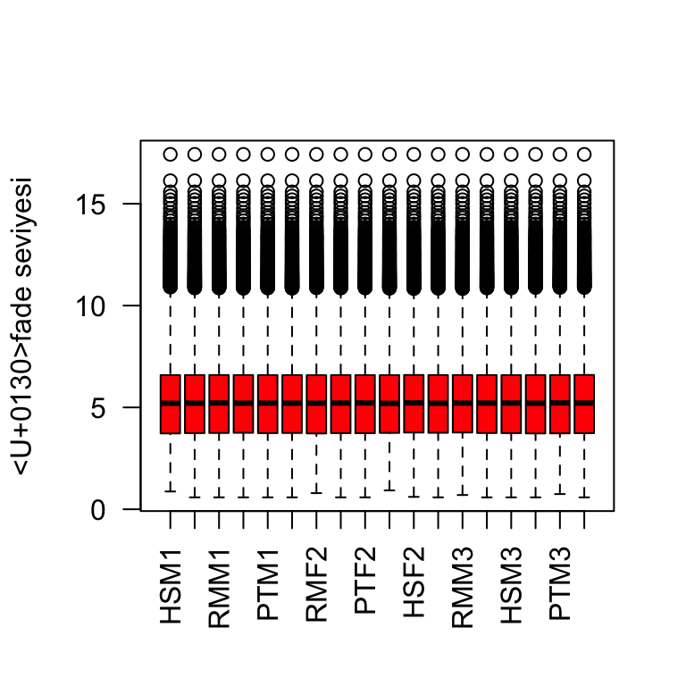

```r
boxplot( nlmat, las=2, col=2, ylab='İfade seviyesi')
```

Gördüğünüz üzere dağılımlar askeri nizama geldi.

## Normalize etmek ya da etmemek

Yüzdelik normalizasyon gürültüyü azaltabilir, ama bu dönüştürmenin farklı örneklerin (sütunların) benzer genel dağılımlara sahip olduğunu varsaydığını unutmamalı. Yüzdelik dağılım ancak örnekler arasında *az sayıda* genin ifadesi fark gösteriyorsa anlamlı olur. Primat karaciğerleri için bu geçerli, ama öneğin karraciğer ve beyin gibi çok farklı dokuları karşılaştırıyorsanız, dağılımları fazla değiştirerek yalancı pozitif sonuçlara yol açabilir.

Dönüştürme veya normalize etme konusunda tereddütte iseniz, itidalli bir yaklaşım veriyi her iki şekilde de işlemek, son aşamada elde edilen sonuçların yöntemler arasında tutarlı olduğunu teyid etmek olur.

# TEMEL BİLEŞENLER ANALİZİ

Türler veya cinsiyetler arasında gen ifadesi farkı testlerine geçmeden önce, verimizin sağlıklı olduğunu son bir kez doğrulamak ve verideki ana varyasyon kaynaklarını kontrol etmek iyi olur.

Burada temel bileşenler analizi (İng. “principal components analysis”) güçlü bir yöntemdir. TBA varyansı bir dizi birbirine dikey temel bileşen (eigenvektör) ile özetler. Bunları varyansa başlıca katkı koyan **temsili genler** olarak hayal edebiliriz. Bu bileşenler açısından örneklerin dağılımını inceleyerek:

- Bu yaklaşımla verideki genel yapıları, başlıca biyolojik ve teknik etkileri inceleyebiliriz.
- Verideki anomalileri tespit edebilir, örneğin **çıkıntı örnekleri** belirleyebilir ve bunları bir ihtimal analizden çıkarabiliriz.
- Teknik varyasyonu yansıttığını tahmin ettiğimiz temel bileşenler veriden teknik varyansın temizlenmesi için kullanılabilir.

Burada önce matrisi `t` fonksiyonuyla devirip, her geni aynı varyansa ölçeklendirip, `prcomp` ile temel bileşenleri hesaplayacağız:

```r
pc <- prcomp(  t( nlmat ), scale=T)

# İlk 6 temel bileşen
summary( pc )$imp[, 1:6 ]
```

```
##                             PC1      PC2      PC3      PC4      PC5      PC6
## Standard deviation     52.50328 40.46251 34.68010 27.40859 25.50359 24.07841
## Proportion of Variance  0.25898  0.15382  0.11299  0.07058  0.06111  0.05447
## Cumulative Proportion   0.25898  0.41280  0.52579  0.59637  0.65748  0.71195
```

Şimdi de çizelim:

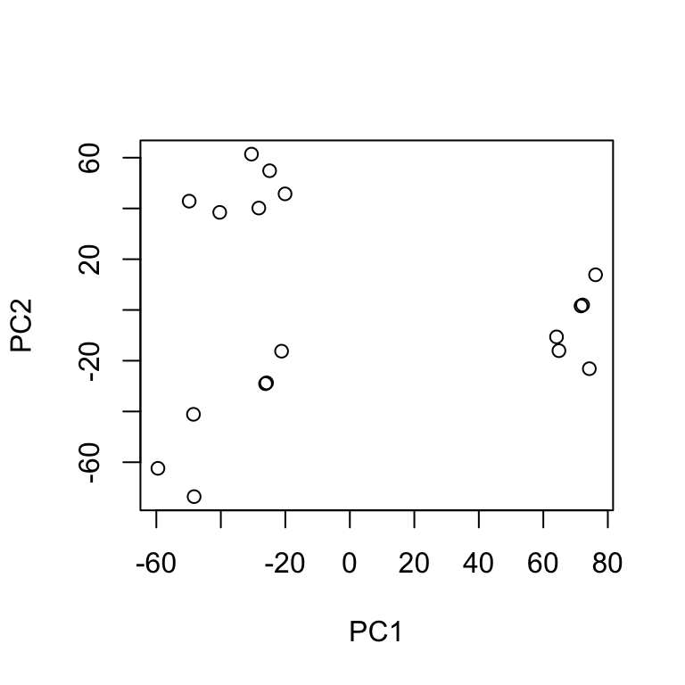

```r
plot( pc$x[,1:2] )
```

Ama kim kim? `text` fonksiyonu ile grafiğe örnek isimlerini ekleyin:

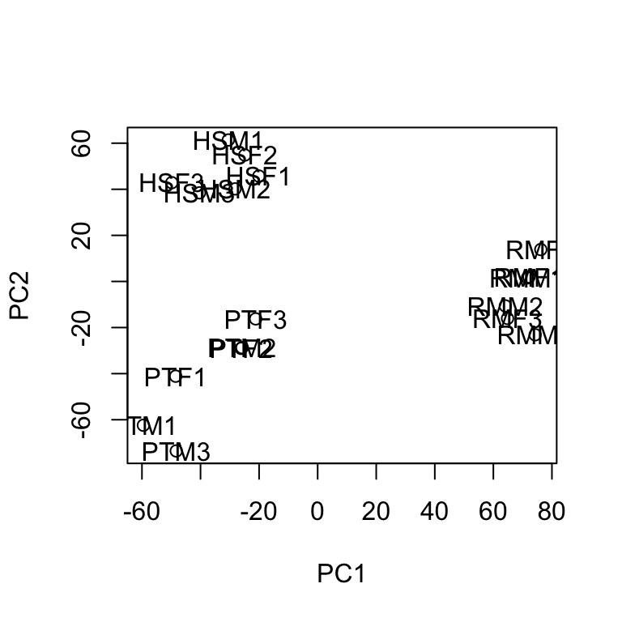

```r
plot( pc$x[,1:2] )
text( pc$x[,1:2], names(pc$x[,1]) )
```

Üçüncü ve dördüncü bileşenlere de bakabiliriz:

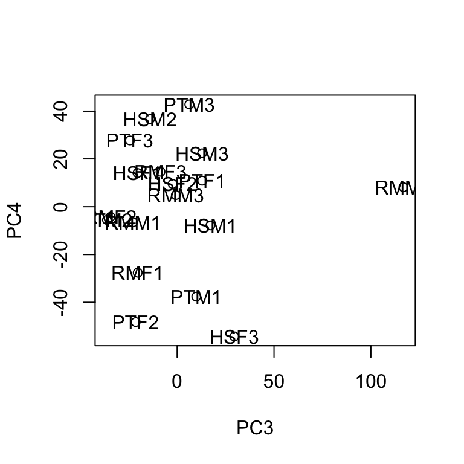

```r
plot( pc$x[,3:4] )
text( pc$x[,3:4], names(pc$x[,1]) )
```

O şebeğin sorunu ne? Çalışmadan çıkarmalı mı?

Yine mutlak doğru bir cevabı olmayan bir soru. İyi bir yaklaşım, **iki türlü de denemek**, yani hem çıkıntı şebekle hem de onsuz analizi yürütmek ve sonuçların söz konusu bireyin varlığına bağlı olmadığına emin olmak olabilir.

# FAKTÖR ÜRETME

Bu noktada TBA grafiğimizi güzelleştirmek için tür ve cinsiyet bilgisi içeren faktör nesneleri üretelim ve bireyleri türlerine veya cinsiyetlerine göre renklendirelim. Bu faktör nesnelerini bir sonraki adımda, ANOVA testinde de kullanacağız.

Tür ve cinsiyet bilgisi sütun isimlerinde saklı. Bunları nasıl çıkrmalı? `substr` fonksiyonu işimizi görür. Önce ilk sütunun ismi üzerinde bir deneme yapalım ve “HSM1”den “HS”yi çekmeye çalışalım.

```r
# Bir örnek
substr("bebek", 2, 4)
```

```
## [1] "ebe"
```

```r
x <- colnames(mat)[1]
substr( x, 1, 2 )
```

```
## [1] "HS"
```

Şimdi bunu tüm bireyler için yapıp `species` isimli bir nesnede toplayalım. Sonra da bunu faktöre çevirelim.

```r
# substr vektörler üzerinde döer
species <- substr ( colnames(mat), 1, 2 )
# Çalıştı mı?
species
```

```
##  [1] "HS" "PT" "RM" "HS" "PT" "RM" "RM" "HS" "PT" "RM" "HS" "PT" "RM" "RM" "HS"
## [16] "PT" "PT" "HS"
```

```r
# Frekanslarına bakalım
table( species )
```

```
## species
## HS PT RM
##  6  6  6
```

```r
species <- as.factor(species)
# Ne fark var?
species
```

```
##  [1] HS PT RM HS PT RM RM HS PT RM HS PT RM RM HS PT PT HS
## Levels: HS PT RM
```

Aynısını cinsiyet için de yapıp bir `sex` nesnesi oluşturalım:

```r
sex <- substr ( colnames(mat), 3, 3 )
sex <- as.factor(sex)
sex
```

```
##  [1] M F M F M F F M F M F M M F M F M F
## Levels: F M
```

```r
table(sex)
```

```
## sex
## F M
## 9 9
```

## Renk vektörü ve TBA’yı renklendirme

Şimdi türler için bir renk vektörü oluşturalım: Kırmızı insan, turuncu şempanze, açık mavi şebek olsun. Bunun daha kısa yolları da var ama açık ve basit olan bir yolu `gsub` kullanıp `species` nesnesindeki kodları renklerle değiştirmek:

```r
# Bir örnek
gsub(pattern = "a", replacement = "de", c("ali", "veli"))
```

```
## [1] "deli" "veli"
```

```r
# İç içe yürütebiliriz
spcols <- gsub("RM", "lightblue",
              gsub("PT", "orange",
                   gsub("HS", "red", species ) ) )
spcols
```

```
##  [1] "red"       "orange"    "lightblue" "red"       "orange"    "lightblue"
##  [7] "lightblue" "red"       "orange"    "lightblue" "red"       "orange"
## [13] "lightblue" "lightblue" "red"       "orange"    "orange"    "red"
```

Şimdi bu renklerle TBA grafiğini çizebiliriz:

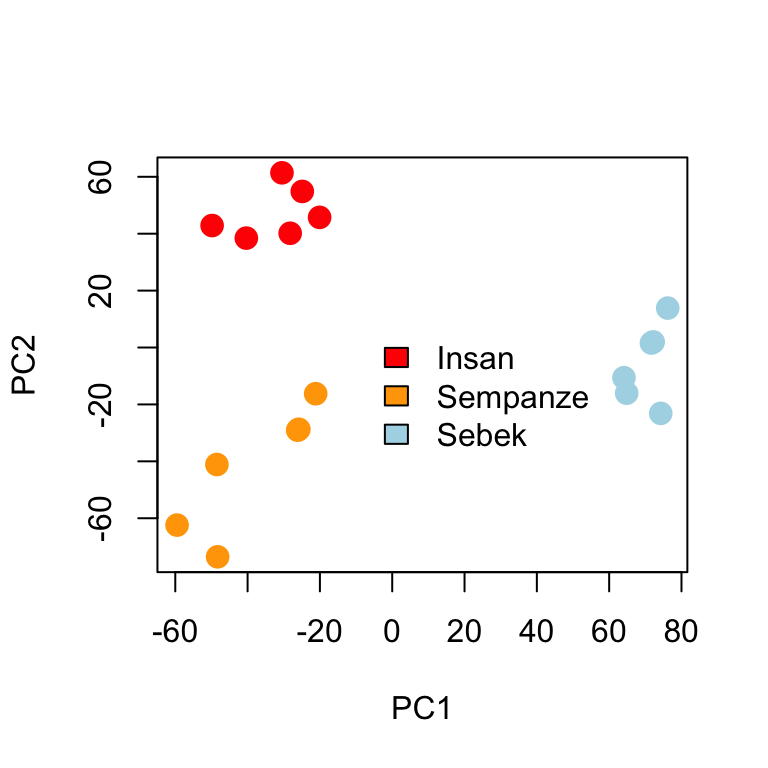

```r
plot( pc$x[,1:2], pch=19, col = spcols, cex=1.5)
# Argümanları kontrol edebilirsiniz
legend( -10, 10, c('Insan', 'Sempanze', 'Sebek'), fill = c("red", "orange", "lightblue"), bty = "n")
```

Evet türler arasında farklar güçlü biçimde görülüyor. İlk TB’nin makağı ayırıyor olması da kümeleme analizinde gördüğümüz örüntüyle uyumlu: evrimsel mesafe gen ifadesi farklılaşmasında en güçlü etki gibi gözüküyor.

# ANOVA İLE İFADE FARKI ANALİZİ

Burada lineer modeller, özel olarak ANOVA ile veri setindeki her geni türler ve cinsiyetler arasında anlamlı fark göstermesi açısından test edeceğiz. Önce ANOVA’nın varsayımlarını hatırlayalım:

- Örnekler bağımsız ve rastgele seçilmiş (teknik replikaları çıkarmış olmamız bu açıdan önemliydi),
- Veriler gruplar içinde normal dağılım gösteriyor,
- Gruplar arasında varyans benzer seviyede (varyans stabilizasyonu bu açıdan önemliydi),
- Artık değerler (İng. “residual”) homojenler.

ANOVA’yı tüm veri setine uygulamadan önce ilk geni seçip, kodumuzu deneyelim.

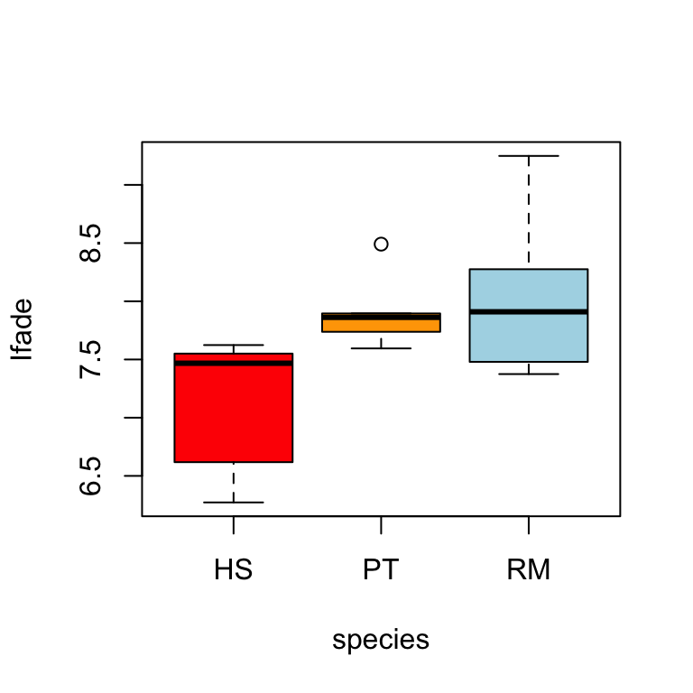

```r
# İlk geni seçelim
y <- nlmat[1,]
boxplot( y ~ species, col=spcols, ylab="Ifade")
```

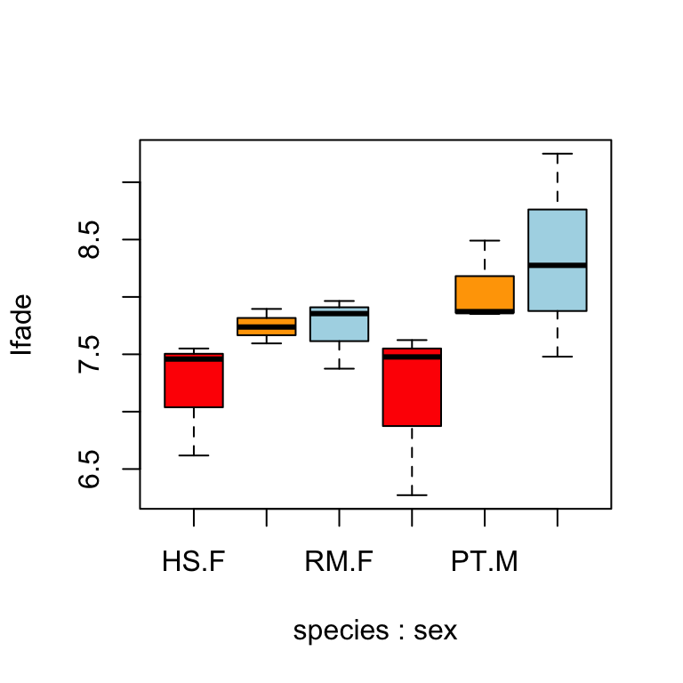

```r
boxplot( y ~ species + sex, col=spcols, ylab="Ifade")
```

```r
# türler arası fark için ANOVA modeli
aov( y ~ species )
```

```
## Call:
##    aov(formula = y ~ species)
##
## Terms:
##                  species Residuals
## Sum of Squares  2.629176  4.423199
## Deg. of Freedom        2        15
##
## Residual standard error: 0.5430285
## Estimated effects may be unbalanced
```

```r
# türler arası fark için test
summary( aov( y ~ species ) )
```

```
##             Df Sum Sq Mean Sq F value Pr(>F)
## species      2  2.629  1.3146   4.458 0.0302 *
## Residuals   15  4.423  0.2949
## ---
## Signif. codes:  0 '***' 0.001 '**' 0.01 '*' 0.05 '.' 0.1 ' ' 1
```

```r
# türler arası ve cinsiyetler arası fark için test
aov( y ~ species + sex )
```

```
## Call:
##    aov(formula = y ~ species + sex)
##
## Terms:
##                  species      sex Residuals
## Sum of Squares  2.629176 0.359013  4.064186
## Deg. of Freedom        2        1        14
##
## Residual standard error: 0.538794
## Estimated effects may be unbalanced
```

```r
summary( aov( y ~ species + sex ) )
```

```
##             Df Sum Sq Mean Sq F value Pr(>F)
## species      2  2.629  1.3146   4.528 0.0304 *
## sex          1  0.359  0.3590   1.237 0.2848
## Residuals   14  4.064  0.2903
## ---
## Signif. codes:  0 '***' 0.001 '**' 0.01 '*' 0.05 '.' 0.1 ' ' 1
```

```r
# türler, cinsiyetler ve etkileşim için test
aov( y ~ species * sex )
```

```
## Call:
##    aov(formula = y ~ species * sex)
##
## Terms:
##                  species      sex species:sex Residuals
## Sum of Squares  2.629176 0.359013    0.359636  3.704550
## Deg. of Freedom        2        1           2        12
##
## Residual standard error: 0.555619
## Estimated effects may be unbalanced
```

```r
summary( aov( y ~ species * sex ) )
```

```
##             Df Sum Sq Mean Sq F value Pr(>F)
## species      2  2.629  1.3146   4.258  0.040 *
## sex          1  0.359  0.3590   1.163  0.302
## species:sex  2  0.360  0.1798   0.582  0.574
## Residuals   12  3.705  0.3087
## ---
## Signif. codes:  0 '***' 0.001 '**' 0.01 '*' 0.05 '.' 0.1 ' ' 1
```

```r
# üretilen nesneden p-değerini çekelim
anova( aov( y ~ species * sex ) )$Pr[1:3]
```

```
## [1] 0.04003661 0.30205762 0.57354977
```

ANOVA’nın gruplar arası varyans ve verinin normalliği konusundaki varsayımının ihlaline karşı, grupla benzer örnek büyüklüğü içeriyorsa aşırı hassas olmadığı belirtilir. Yine de dilersek Shapiro testi gibi araçlarla her bir gen için varsayımların geçerliliğini sınayabilirdik.

Burada ayrıca ANOVA’dan farklı yaklaşımlarla da fark ölçmek mümkün. Örneğin non-parametrik test, ham veriyi kullanarak bireyi rastgele faktör olarak içeren karışık modeller, negatif binomiyal dağılıma dayanan testler kullanmak, gibi.

RNA-dizileme veri analizinde yaygın kullanılan `DESeq2` ve `edgeR` gibi R paketlerinin de ANOVA değil negatif binomiyal dağılım kullandıklarını, ama daha da ötesinde veride gen uzunlukları ve GC farklarına göre düzeltmeler uyguladıklarını, ayrıca gen başına varyans tahmininde genler arasında bilgi paylaştıklarını belirtebiliriz.

## Tüm veri setinde ANOVA:

Şimdi tüm veri setinde tür, cinsiyet ve etkileşimleriyle ANOVA yürütelim:

```r
nlmat_aovp <- apply(nlmat, 1, function(y)
  anova( aov( y ~ species * sex ) )$Pr[1:3] )
dim(nlmat_aovp)
nlmat_aovp <- t(nlmat_aovp)
colnames( nlmat_aovp ) <- c('sp', 'sex', 'int')
# veriyi üretmesi uzun olduğu için kaydedelim ki, gerekirse tekrar yükleyebilelim
save( nlmat_aovp, file = "nlmat_aovp.Rdata")
```

```r
head(nlmat_aovp)
```

```
##                          sp        sex       int
## ENSG00000000003 0.040036605 0.30205762 0.5735498
## ENSG00000000419 0.842938544 0.93412736 0.5732420
## ENSG00000000457 0.008793507 0.02530931 0.5410162
## ENSG00000000460 0.022072219 0.36588480 0.7039392
## ENSG00000000938 0.382809048 0.82457926 0.5444900
## ENSG00000000971 0.004766938 0.15989154 0.8427885
```

Şimdi doğru işleyip işlemediğini öğrenmek için en anlamlı ve en anlamsız genlere bakalım:

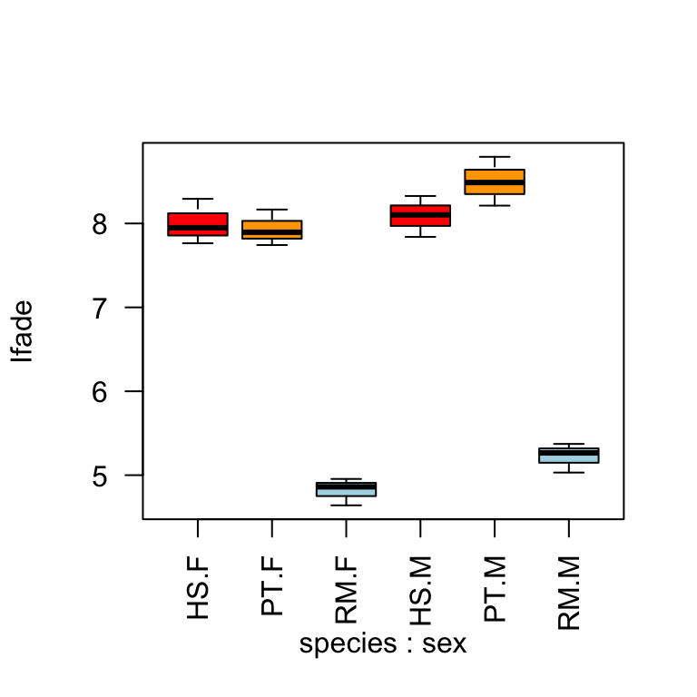

```r
i <- which.min ( nlmat_aovp[,'sp'] )
y <- nlmat [i, ]
boxplot ( y ~ species * sex, col=spcols, ylab='Ifade', las=2)
```

Tür-cinsiyet etkileşimlerine bakalım:

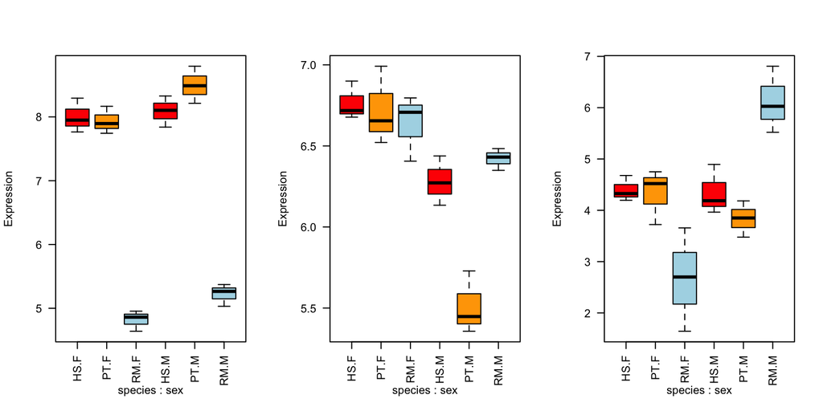

[output not shown]

[output cut: 24 more lines]

[output not shown]

```r
par(mfrow=c(1,3))
# most significant genes
apply(nlmat_aovp, 2, function(x)  {
  y <- nlmat [which.min ( x ), ]
  boxplot ( y ~ species * sex, col=spcols, ylab='Expression', las=2)
})
```

Şimdi de *en az anlamlı* genlere bakalım:

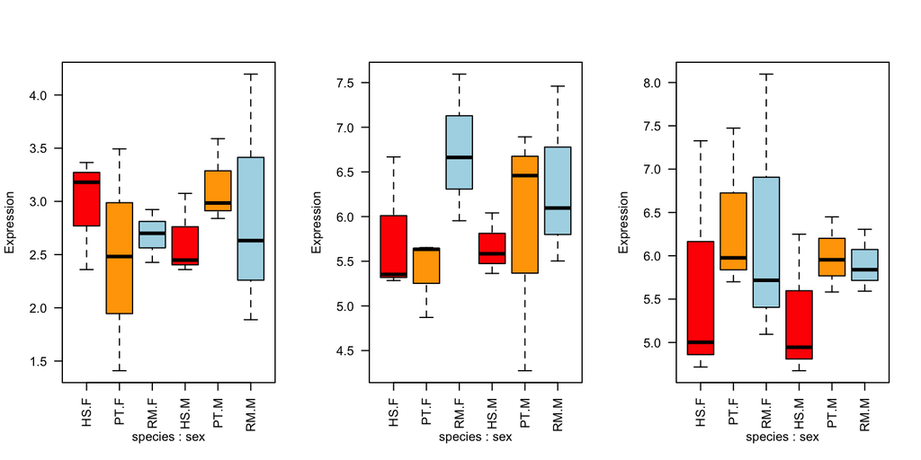

[output not shown]

[output cut: 24 more lines]

[output not shown]

```r
par(mfrow=c(1,3))
apply(nlmat_aovp, 2, function(x)  {
  y <- nlmat [which.max ( x ), ]
  boxplot ( y ~ species * sex, col=spcols, ylab='Expression', las=2)
})
```

Evet çalışmış gibi. Peki p-değeri dağılımları ne?

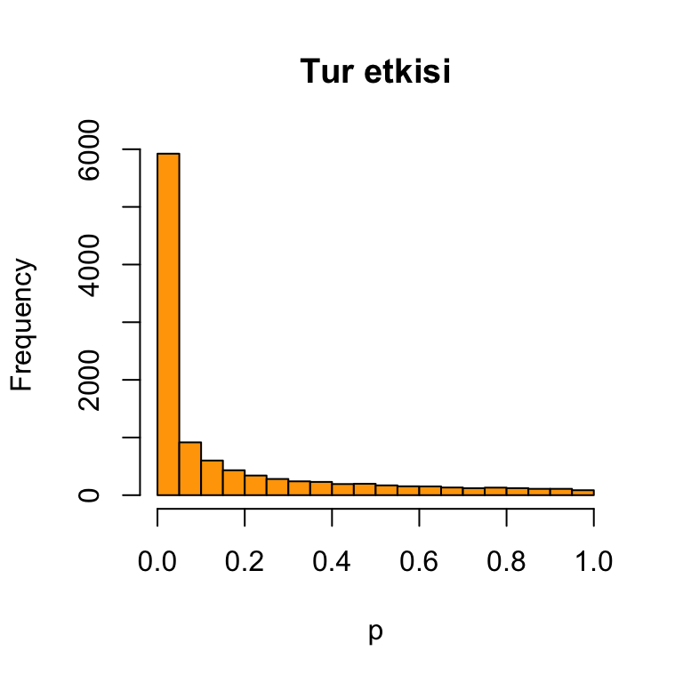

```r
# histogram
hist( nlmat_aovp[,"sp"], xlab='p', col="orange", main="Tur etkisi" )
```

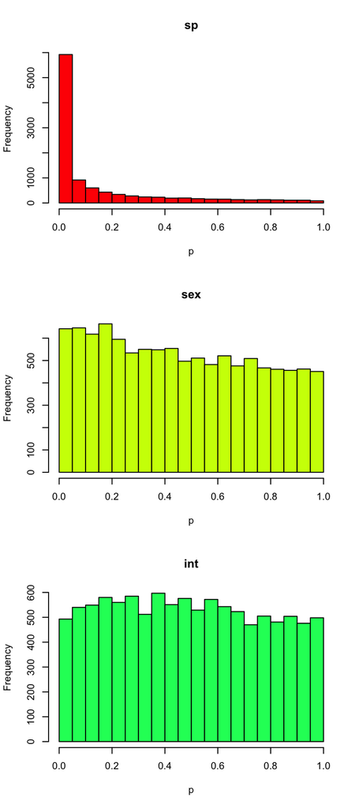

```
##          [,1]              [,2]              [,3]
## breaks   Numeric,21        Numeric,21        Numeric,21
## counts   Integer,20        Integer,20        Integer,20
## density  Numeric,20        Numeric,20        Numeric,20
## mids     Numeric,20        Numeric,20        Numeric,20
## xname    "nlmat_aovp[, i]" "nlmat_aovp[, i]" "nlmat_aovp[, i]"
## equidist TRUE              TRUE              TRUE
```

```r
par( mfrow=c(3,1))
sapply(1:3, function(i) {
  hist( nlmat_aovp[,i], xlab='p', col=rainbow(5)[i], main=colnames(nlmat_aovp)[i])
})
```

Peki 0.05’in altındaki genlerin oranı ne?

```r
# p<0.05 vakaları
apply(nlmat_aovp < 0.05, 2, mean)
```

```
##         sp        sex        int
## 0.55646374 0.06031567 0.04631717
```

Acaba bu sayıların gerçekten anlamlı olduğunu, yani rastgele olmadığını, söyleyebilir miyiz?

# ÇOKLU TEST DÜZELTMESİ

Rastgele verilerle üretilen p-değerlerinin nasıl dağılmasını bekleriz? Hemen ufak bir simülasyonla ölçelim.

```r
set.seed(1)
t.test(runif(6), runif(6))$p.val
```

```
## [1] 0.6470367
```

```r
t.test(runif(6), runif(6))$p.val
```

```
## [1] 0.3367366
```

```r
ranp <- sapply( 1:10000, function(i) {   # here i is just a counter, no role inside the loop
  t.test(runif(6), runif(6))$p.val
})
mean( ranp < 0.05 )
```

```
## [1] 0.053
```

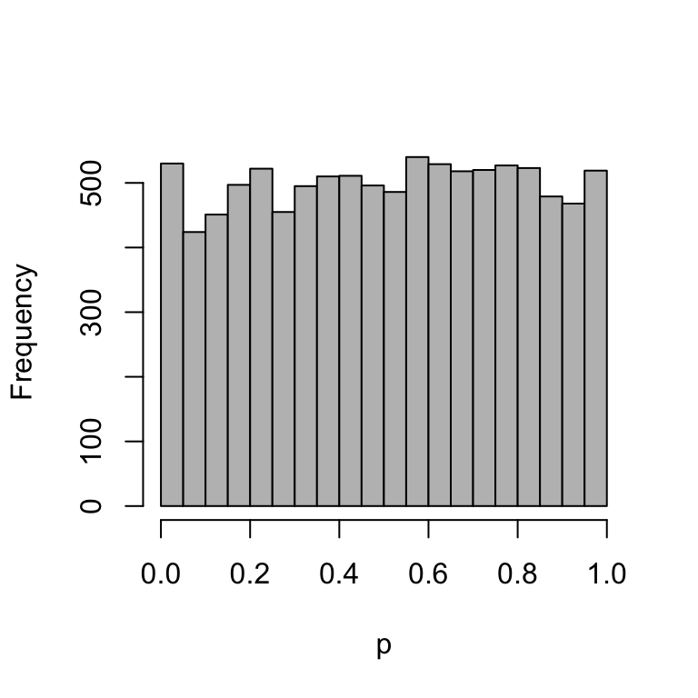

```r
hist( ranp, xlab='p', col=8, main="")
```

Görüldüğü üzere rastgele p-değerleri eş oranlı dağılıyor. Bu durumda ANOVA’daki üç etmenin gerçek etkileri konusunda ne diyebiliriz?

Şunu da görüyoruz: Bin test yaparsanız 50’sinin p-değeri 0.05’ten küçük olacak. Bu durumda sahte pozitifleri nasıl kontrol edebiliriz?

- R’daki `p.adjust` fonksiyonuyla Bonferroni, Benjamini-Hochberg (BH), veya Benjamini-Yekutieli (BY) gibi algoritmalardan biriyle p-değerleri üzerinde çoklu test düzeltmesi uygulanabilir.
- Rastgele permütasyon ile rastgele veriyle ne kadar “nominal olarak anlamlı” p-değeri üretileceğini belirlemek.

Burada, testler arasında bağımsızlık olduğunu varsaymayan BY düzeltmesini kullanacağız. Artık p-değerlerimiz sahte pozitif oranlarına (İng. “false discovery rate”) dönüşecek.

```r
head(nlmat_aovp)
```

```
##                          sp        sex       int
## ENSG00000000003 0.040036605 0.30205762 0.5735498
## ENSG00000000419 0.842938544 0.93412736 0.5732420
## ENSG00000000457 0.008793507 0.02530931 0.5410162
## ENSG00000000460 0.022072219 0.36588480 0.7039392
## ENSG00000000938 0.382809048 0.82457926 0.5444900
## ENSG00000000971 0.004766938 0.15989154 0.8427885
```

```r
nlmat_aovpc <- apply(nlmat_aovp, 2, function(x) p.adjust( x, 'BY'))
dim(nlmat_aovpc)
```

```
## [1] 10644     3
```

```r
head(nlmat_aovpc)
```

```
##                        sp sex int
## ENSG00000000003 0.7455430   1   1
## ENSG00000000419 1.0000000   1   1
## ENSG00000000457 0.2376753   1   1
## ENSG00000000460 0.4730437   1   1
## ENSG00000000938 1.0000000   1   1
## ENSG00000000971 0.1498150   1   1
```

Şimdi ne kadar anlamlı gen var?

```r
apply(nlmat_aovpc < 0.05, 2, mean)
```

```
##        sp       sex       int
## 0.2093198 0.0000000 0.0000000
```

```r
apply(nlmat_aovpc < 0.1, 2, mean)
```

```
##        sp       sex       int
## 0.2741451 0.0000000 0.0000000
```

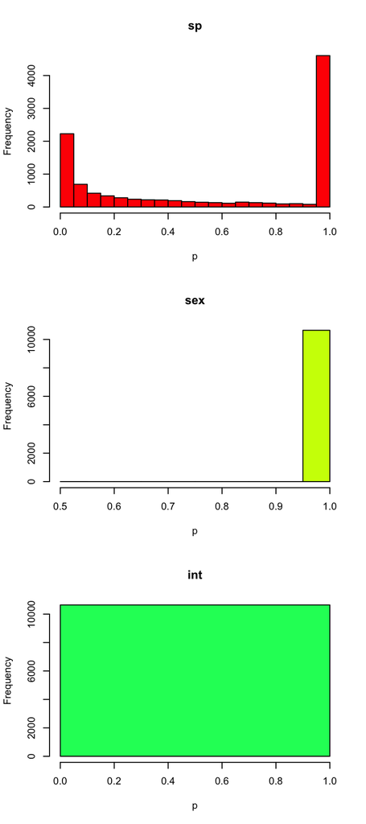

```r
par(mfrow=c(3,1))
for (i in 1:3) {
  hist( nlmat_aovpc[,i], xlab='p', col=rainbow(5)[i], main=colnames(nlmat_aovpc)[i])
}
```

Yani transkriptomun %20 kadarı tür etkisi gösterirken, cinsiyet ve tür-cinsiyet etkileşimi açısından anlamlı gen bulunmuyor.

**Monte Carlo** yaklaşımıyla rastgele permütasyonlar yürüterek (örnekleri rastgele karıştırıp örneğin “sahte türler” arası farklar hesaplayarak) nasıl test gerçekleştirilebileceğini ek belgede inceleyebilirsiniz.

# İŞLEVSEL ANALİZ

İfade farkı gösteren genleri bulduktan sonra araştırmacılar, bu genlerin işlevleri veya regülasyonları hakkında bilgi toplamaya çalışır. Bunun için genellikle ya tüm fark gösteren genler, ya da spesifik bir ifade farkı örüntüsü gösteren genler seçilir; insanda diğer türlere kıyasla yüksek anlatılan genler gibi.

Ardından bu odak gen grubu fark göstermeyenlere kıyaslanır (veya başka tip fark örüntüsü sergileyenlere kıyaslanır) ve odak genlerin:

1. Hangi işlevsel gruplarda, örneğin Gene Ontology gruplarında yoğunlaştığı,
2. Hangi kromozomlarda veya kromozom bölgelerinde yoğunlaştığı,
3. Ne tip regülatörlerinin olduğunu (örneğin promotörlerinde yoğunlaşan TF’lerin varlığı),
4. Bu genlerin dizilerinin nasıl evrildiğini, türler arasında veya tür içinde görülen dizi farklılaşması veya koruması gibi konular incelenir.

Örneğin burada da türler arası gen ifadesi farkı gösteren genleri k-ortalama gibi bir yöntemle ifade seviyelerine göre kümeleyip, sonra diyelim ki insanda diğer türlerden yüksek anlatılan gen grubunu seçip, bunların ortak işlevsel özelliklerini inceleyebilir, bunun için söz konusu gen grubunun yoğunlaştığı GO gruplarını `topGO` paketiyle test edebilirdik. Bu yöntem tüm GO grupları üzerinde Fisher kesin testi uygular; ardından yine çoklu test düzeltmesi gereklidir.

Bu analizler ve kimi kısıtlarıyla ilgili ek belgeyi inceleyebilirsiniz.

# BIOMART İLE KROMOZOM YOĞUNLAŞMA ANALİZİ

Son alıştırmamızda, nominal olarak cinsiyete göre fark gösteren genlerin, cinsiyet kromozomlarında yoğunlaşma gösterip göstermediğini test edeceğiz. Bu makul bir hipotez olabilir çünkü Y genleri yalnızca erkeğe özgü (gerçi çoğu testiste anlatılıyor), X genlerininse tümü dişilerde tamamen susturulmuyor.

Burada önce genlerin bulunduklaı kromozomları Ensembl’dan indirmemiz gerek. Bunun için `biomaRt` paketini kullanacağız. Sonra da cinsiyetle ilgili ve ilgisiz genlerin, cinsiyet kromozomlarında ve otozomlarda dağılımını Fisher kesin testiyle inceleyeceğiz.

Paketi oturuma yükleyelim:

```r
library(biomaRt, verbose = F, quietly = T)
listMarts()
```

| biomart | version |
| --- | --- |
| ENSEMBL_MART_ENSEMBL | Ensembl Genes 99 |
| ENSEMBL_MART_MOUSE | Mouse strains 99 |
| ENSEMBL_MART_SNP | Ensembl Variation 99 |
| ENSEMBL_MART_FUNCGEN | Ensembl Regulation 99 |

```r
ens <- useMart(
  biomart="ENSEMBL_MART_ENSEMBL",
  host="grch37.ensembl.org",
  path="/biomart/martservice",
  dataset="hsapiens_gene_ensembl")
ensChrTable <- unique( getBM( attributes=c("ensembl_gene_id", "chromosome_name"),
                              filters="", mart=ens) )
```

```
## Cache found
```

```r
dim( ensChrTable )
```

```
## [1] 63677     2
```

```r
# tablo niye bu kadar büyük? 25 bin gen yok muydu?

head( ensChrTable )
```

|  | ensembl_gene_id | chromosome_name |
| --- | --- | --- |
| 1 | ENSG00000261657 | HG991_PATCH |
| 2 | ENSG00000223116 | 13 |
| 3 | ENSG00000233440 | 13 |
| 4 | ENSG00000207157 | 13 |
| 5 | ENSG00000229483 | 13 |
| 6 | ENSG00000252952 | 13 |

```r
tt <- table( ensChrTable[,2])
tt[1:30]
```

```
##
##          1         10         11         12         13         14         15
##       5363       2260       3208       2818       1217       2244       2080
##         16         17         18         19          2         20         21
##       2343       2903       1127       2910       4047       1317        736
##         22          3          4          5          6          7          8
##       1263       3101       2563       2859       2905       2876       2386
##          9 GL000191.1 GL000192.1 GL000193.1 GL000194.1 GL000195.1 GL000196.1
##       2323          2          7          7          3          2          1
## GL000199.1 GL000201.1
##          2          2
```

Sadece standart kromozomlardaki genlere göz atalım:

```r
tt[names(tt) %in% c(as.character(1:22), "X", "Y")]
```

```
##
##    1   10   11   12   13   14   15   16   17   18   19    2   20   21   22    3
## 5363 2260 3208 2818 1217 2244 2080 2343 2903 1127 2910 4047 1317  736 1263 3101
##    4    5    6    7    8    9    X    Y
## 2563 2859 2905 2876 2386 2323 2392  495
```

Şimdi 4 gen listesi belirlememiz gerekiyor (neyse ki hepsi Ensembl):

- nominal olarak cinsiyete göre ifade farkı gösterenler,
- ifade farkı göstermeyenler,
- Cinsiyet kromozomlarında (X veya Y) olanlar,
- otozomal genler.

## Cinsiyete göre ifade farkı gösteren genler

Burada düzeltilmemiş p-değerlerini kullanacağız, yalnızca alıştırma amaçlı olduğunu için:

```r
de_sex_genes <- names( which( nlmat_aovp[,"sex"] < 0.05 ) )
node_sex_genes <- names( which( nlmat_aovp[,"sex"] >= 0.05 ) )
length(de_sex_genes)
```

```
## [1] 642
```

```r
length(node_sex_genes)
```

```
## [1] 10002
```

```r
# iki vektör arasında kesişme olmadığını kontrol edelim
intersect(de_sex_genes, node_sex_genes)
```

```
## character(0)
```

## Cinsiyet kromozomlarındaki genler:

Burada iki vektör arasında ortak elemanları ararken, `%in%` operatörünün kullanımına dikkat; `==` aynı işi görmezdi.

```r
head(ensChrTable)
```

|  | ensembl_gene_id | chromosome_name |
| --- | --- | --- |
| 1 | ENSG00000261657 | HG991_PATCH |
| 2 | ENSG00000223116 | 13 |
| 3 | ENSG00000233440 | 13 |
| 4 | ENSG00000207157 | 13 |
| 5 | ENSG00000229483 | 13 |
| 6 | ENSG00000252952 | 13 |

```r
sex_chr_genes <- ensChrTable$ensembl_gene_id [ ensChrTable$chromosome_name %in% c('X', 'Y') ]
nosex_chr_genes <- ensChrTable$ensembl_gene_id [ ensChrTable$chromosome_name %in% as.character(1:22) ]
```

Şimdi her iki grup vektör arasında kesişmeleri belirlememiz gerekiyor. Bunun için `length` ve `intersect` fonksiyonlarını kullanacağız. Tekrardan kaçınmak için de ufak bir fonksiyon kendimiz yazacağız. Adına `loi` diyeceğimiz bu fonksiyon, x ve y isimli iki vektör arasında kesişen elemanlarını sayısını çıkaracak.

```r
loi <- function(x, y) {
  length( intersect( x, y ) )
}

loi(c("a", "b", "c", "d"), c("e", "c", "b"))
```

```
## [1] 2
```

Şimdi de Fisher kesin testi uygulayalım. Tek yanlı test uygulayabiliriz.

```r
overlaps <- c(
  loi( de_sex_genes, sex_chr_genes ),
  loi( de_sex_genes, nosex_chr_genes ),
  loi( node_sex_genes, sex_chr_genes ),
  loi( node_sex_genes, nosex_chr_genes ) )

matx <- matrix ( overlaps, 2, 2 )
matx
```

```
##      [,1] [,2]
## [1,]   25  292
## [2,]  598 9494
```

```r
fisher.test( matx, alt='greater')
```

```
##
##  Fisher's Exact Test for Count Data
##
## data:  matx
## p-value = 0.09538
## alternative hypothesis: true odds ratio is greater than 1
## 95 percent confidence interval:
##  0.9246913       Inf
## sample estimates:
## odds ratio
##   1.359215
```

Sonuçta anlamlı bir örtüşme göremiyoruz (test tek taraflı olduğu halde). Öte yandan zayıf bir eğilim olması, acaba örneğin dişilerde yüksek anlatılan genlerle testi yürütseydik, sonuç anlamlı olur muydu, sorusunu akla getiriyor.